# Translation Requirement

Trisha Gupta

As per the survey data, translation cost was incurred. I plotted this visual representation to check if we really need to invest in translation and came up with this simple bar graph using R.

Because if we don’t, the same money can be used in improving other facets of our asking of data, such as a form which is has improved UI features so as to make it look better and more interesting.

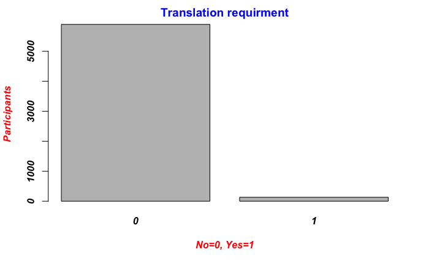

The survey was presented in English by default. The introductory text included directions to finding selecting an alternative language (Traditional Chinese, Japanese, Spanish, and Russian). Translations were obtained through a paid vendor, with validation and corrections from the open source community via the public project repository.

TRANSLATED indicates whether a respondent completed the English version of the questionnaire (0) or one of the translations (1). Hence, the graph ‘Translation requirement’ helps us analyze how much translation is required. It particularly shows that majority of the people used the English version of the questionnaire. Very few people made use of the translations. This can be because of two reasons: a) they were well versed with English b) their language choice was not in the options and so they used the default language.

In situation where translation is required, it would indeed make the project less accessible. However as per the graph, we barely need translation, as very few people are making use of it.